# Static-III

Tommy Yu

October 23, 2017

```r
my_theme <- theme(plot.title=element_text(color="#02818a", vjust=18, size=36, family="Bernard MT Condensed"),
                  plot.subtitle = element_text(color="#1a1a1a", vjust=10, size=24, family="Candara"),
                  plot.background = element_rect(fill="#f7fcfd"),
                  axis.title = element_text(color="#02818a", size=24, family="Candara"),
                  axis.title.y = element_text(margin = margin(r = 18)),
                  axis.title.x = element_text(margin = margin(t = 18)),
                  axis.text = element_text(color="#1a1a1a", size=18, family="Candara"),
                  legend.title = element_text(color="#02818a", size=24, family="Candara"),
                  legend.text = element_text(color="#1a1a1a", size=18, family="Candara"),
                  legend.box.background = element_rect(color="#02818a"),
                  strip.text = element_text(color="white", size=18, family="Candara"),
                  strip.background = element_rect(fill="#02818a"),
                  panel.grid.major = element_line(color="#02818a", size=0.5),
                  panel.grid.minor = element_line(color="#02818a", linetype = "dotted", size=0.25),
                  panel.background = element_rect(fill="white"),
                  panel.border = element_rect(color="white",fill=NA),
                  plot.caption = element_text(color="#1a1a1a",size=18, vjust=-15, family="Candara"),
                  plot.margin = margin(3, 1, 3, 2, "cm"))

qualitative <- "Set2"
sequential <- "GnBu"
diverging <- "PRGn"
```

## Graph 1

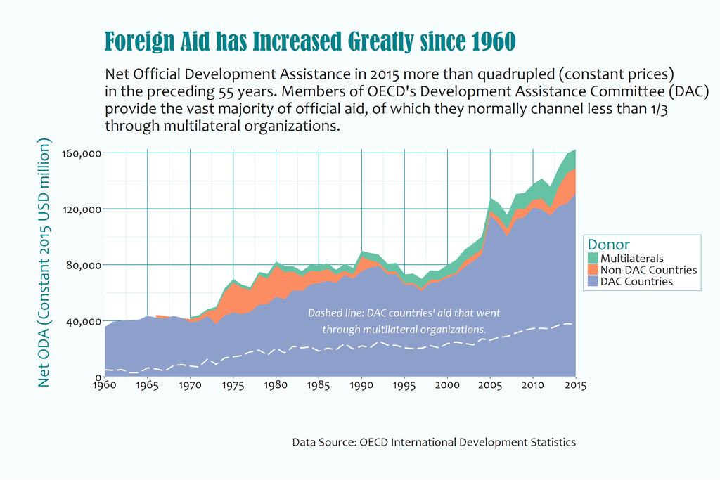

```r
ggplot() +
  geom_area(data=by_donor, aes(x= Year, y = Value, fill = Donor), position = "stack") +
  geom_line(data=DAC_multi, aes(x = Year, y = Value), size=1, color="white", linetype="longdash") +
  scale_fill_manual(values=brewer.pal(3, qualitative),
                    labels=c("Multilaterals", "Non-DAC Countries", "DAC Countries")) +
  scale_y_continuous(expand = c(0, 0), labels = scales::comma) +
  scale_x_continuous(expand = c(0, 0), breaks = (seq(1960,2015,5)), labels=(seq(1960,2015,5))) +
  annotate("text", x = 1995, y = 40000, label = "Dashed line: DAC countries' aid that went\nthrough multilateral organizations.", size=6, family="Candara", color="white", fontface="italic") +
  labs(title = "Foreign Aid has Increased Greatly since 1960",
       subtitle = "Net Official Development Assistance in 2015 more than quadrupled (constant prices)\nin the preceding 55 years. Members of OECD's Development Assistance Committee (DAC)\nprovide the vast majority of official aid, of which they normally channel less than 1/3\nthrough multilateral organizations.",
       caption = "Data Source: OECD International Development Statistics",
       x = "",
       y = "Net ODA (Constant 2015 USD million)") +
  my_theme
```

> There has been a general trend of increase in Official Development Assistance (ODA) since 1960 (based on constant 2015 dollars), despite a few occasional drops. In fact, Net ODA in 2015 more than quadrupled compared to that in 1960. Members of OECD’s Development Assistance Committee (DAC) provide the vast majority of official aid. Although they send most of their aid directly to other countries through bilateral agreements, they normally channel the remaining portion (less than 1/3) through multilateral organizations.

## Graph 2

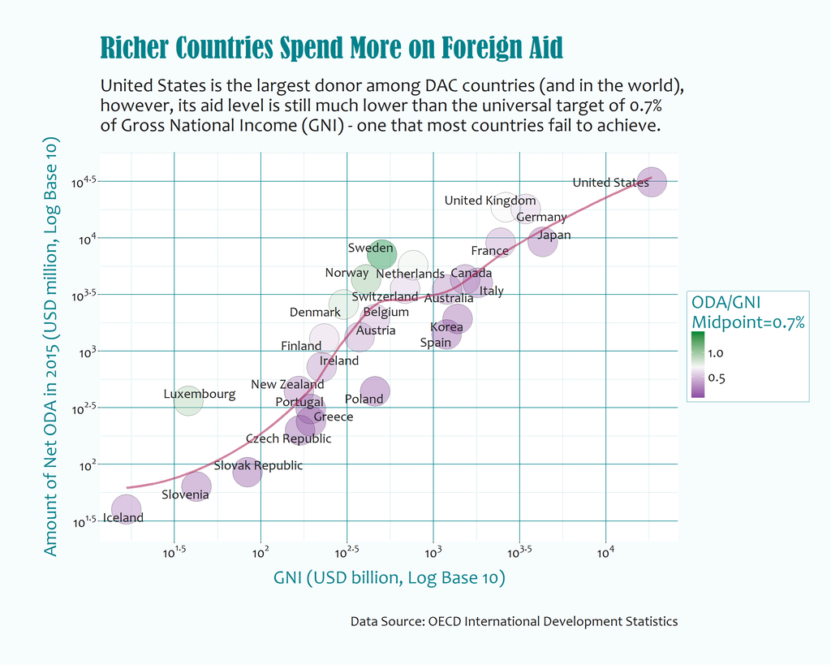

```r
GNI %>%
  ggplot(aes(x = GNI, y = ODA, color=`ODA/GNI`)) +
  geom_point(size=18, alpha=0.4)+
  geom_point(shape = 1,size = 18,colour = "black", alpha=0.5)+
  scale_y_log10(breaks = trans_breaks("log10", function(x) 10^x),
                labels = trans_format("log10", math_format(10^.x)),
                limits = c(30, 40000))+
  scale_x_log10(breaks = trans_breaks("log10", function(x) 10^x),
                labels = trans_format("log10", math_format(10^.x)))+
  scale_colour_gradient2(low = head(color, n=1), mid = color[3],
                         high = tail(color, n=1), midpoint = 0.7)+
  geom_text_repel(size=6, color="#1a1a1a", family="Candara", aes(label=Country))+
  geom_line(stat="smooth", method="loess", color="maroon", size=1.5, alpha=0.6)+
  theme_bw()+
  labs(title = "Richer Countries Spend More on Foreign Aid",
       subtitle = "United States is the largest donor among DAC countries (and in the world),\nhowever, its aid level is still much lower than the universal target of 0.7%\nof Gross National Income (GNI) - one that most countries fail to achieve.",
       caption = "Data Source: OECD International Development Statistics",
       x = "GNI (USD billion, Log Base 10)",
       y = "Amount of Net ODA in 2015 (USD million, Log Base 10)",
       color = "ODA/GNI\nMidpoint=0.7%") +
  my_theme
```

## Graph 3

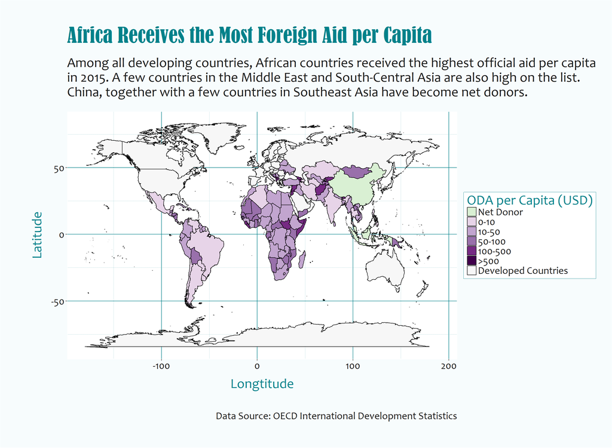

```r
map.world %>%
  left_join(rec, by="region") %>%
  ggplot() +
  geom_map(map=map.world, color="black", aes(map_id=region, x=long, y=lat, fill=cat))+
  scale_fill_manual(values = rev(brewer.pal(10, diverging))[5:10], na.value="#f7f7f7", labels = c("Net Donor","0-10","10-50","50-100","100-500",">500","Developed Countries")) +
  labs(title="Africa Receives the Most Foreign Aid per Capita",
       subtitle="Among all developing countries, African countries received the highest official aid per capita\nin 2015. A few countries in the Middle East and South-Central Asia are also high on the list.\nChina, together with a few countries in Southeast Asia have become net donors.",
       x="Longtitude",
       y="Latitude",
       fill="ODA per Capita (USD)",
       caption = "Data Source: OECD International Development Statistics") +
  my_theme
```

> Among all developing countries, African countries received the highest official aid per capita in 2015. A few countries in the Middle East and South-Central Asia are also high on the list. China, together with a few countries in Southeast Asia have become net donors.

## Graph 4

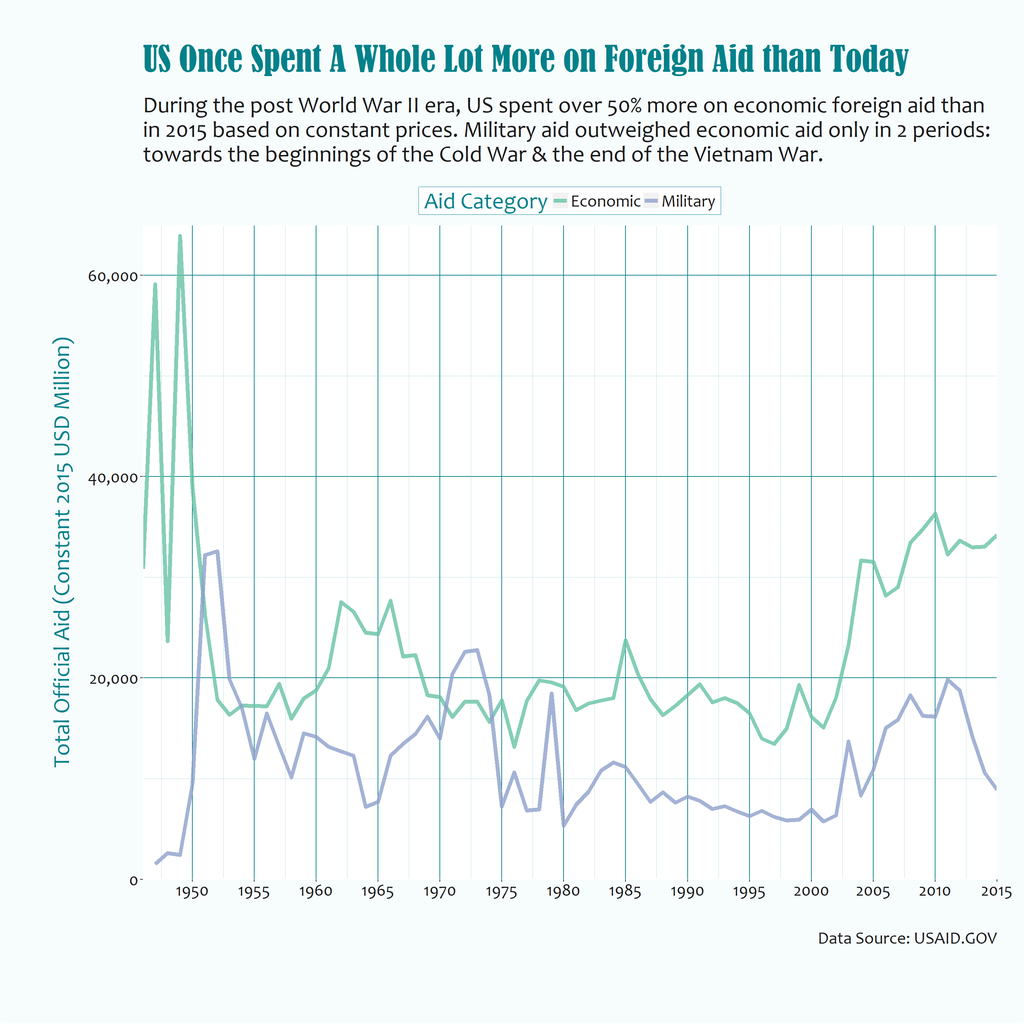

```r
us %>%
  ggplot(aes(x=fiscal_year, y=Amount, group=assistance_category_name))+
  geom_line(size=2, alpha=0.8, aes(color=assistance_category_name))+
  scale_y_continuous(limits=c(0, 65000), expand=c(0,0), labels = scales::comma) +
  scale_x_continuous(expand = c(0, 0), breaks = (seq(1940,2015,5)), labels=(seq(1940,2015,5))) +
  scale_color_manual(values=c("#66c2a5", "#8da0cb"))+
  labs(title="US Once Spent A Whole Lot More on Foreign Aid than Today",
       subtitle="During the post World War II era, US spent over 50% more on economic foreign aid than\nin 2015 based on constant prices. Military aid outweighed economic aid only in 2 periods:\ntowards the beginnings of the Cold War & the end of the Vietnam War.",
       x="",
       y="Total Official Aid (Constant 2015 USD Million)",
       color="Aid Category",
       caption = "Data Source: USAID.GOV") +
  my_theme +
  theme(legend.position = "top")
```

> ODA as defined by OECD does not take into account aid for military purposes. Therefore, it is interesting to look at US foreign aid, which has a clear classification of economic vs. military. Surprisinlgy, during the post World War II era, US spent over 50% more on economic foreign aid than in 2015 based on constant prices. Military aid outweighed economic aid only in 2 periods: towards the beginnings of the Cold War & the end of the Vietnam War. There is a strong correlation between economic aid and military aid over the past 30 years, until most recently when military aid started to drop.

## Graph 5

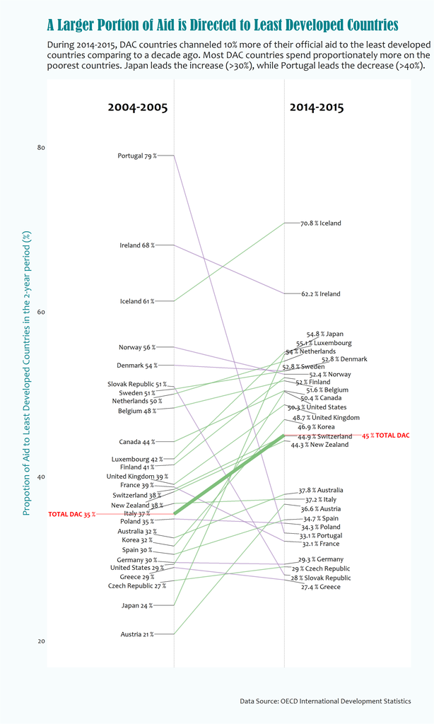

```r
ggplot() +
  geom_segment(data=ind, aes(x=1.2, xend=1.8, y=A, yend=B, col=class), size=1, alpha=0.75, show.legend=F) +
  geom_text_repel(data=ind, label=left_i, y=ind$A, x=1.2, size=6, nudge_x = -0.2, family="Candara")+
  geom_text_repel(data=ind, label=right_i, y=ind$B, x=1.8, size=6, nudge_x = 0.2, family="Candara")+
  geom_segment(data=tot, aes(x=1.2, xend=1.8, y=A, yend=B, col=class), size=4, show.legend=F) +
  geom_text_repel(data=tot, label=left_t, y=tot$A, x=1.2, size=6, fontface="bold", color="red", nudge_x = -0.6, family="Candara")+
  geom_text_repel(data=tot, label=right_t, y=tot$B, x=1.8, size=6, fontface="bold", color="red", nudge_x = 0.6, family="Candara")+
  geom_vline(xintercept=1.2, linetype="dashed", size=.1) +
  geom_vline(xintercept=1.8, linetype="dashed", size=.1) +
  scale_color_manual(labels = c("Up", "Down"),
                     values = c("inc"="#7fbf7b", "dec"="#af8dc3")) +
  xlim(.6, 2.4) + ylim(20,85)+
  annotate("text", label="2004-2005", x=1.2, y=85, hjust=1.1, size=12, fontface="bold", family="Candara") +
  annotate("text", label="2014-2015", x=1.8, y=85, hjust=-0.1, size=12, fontface="bold", family="Candara") +
  labs(title="A Larger Portion of Aid is Directed to Least Developed Countries",
       subtitle="During 2014-2015, DAC countries channeled 10% more of their official aid to the least developed\ncountries comparing to a decade ago. Most DAC countries spend proportionately more on the\npoorest countries. Japan leads the increase (>30%), while Portugal leads the decrease (>40%).",
       x="",
       y="Propotion of Aid to Least Developed Countries in the 2-year period (%)",
       caption = "Data Source: OECD International Development Statistics") +
  my_theme+
  theme(panel.grid.major = element_blank(),
        panel.grid.minor = element_blank(),
        axis.ticks = element_blank(),
        axis.text.x = element_blank(),
        panel.border = element_blank(),
        plot.margin = unit(c(3,2,3,2), "cm"))
```

> During 2014-2015, DAC countries channeled 10% more of their official aid to the least developed countries comparing to a decade ago. Most DAC countries spend proportionately more on the poorest countries. Japan leads the increase (>30%), while Portugal leads the decrease (>40%). Iceland and Ireland appear to have been directing the most portion of their aid to least developed countries (>60%).

## Graph 6

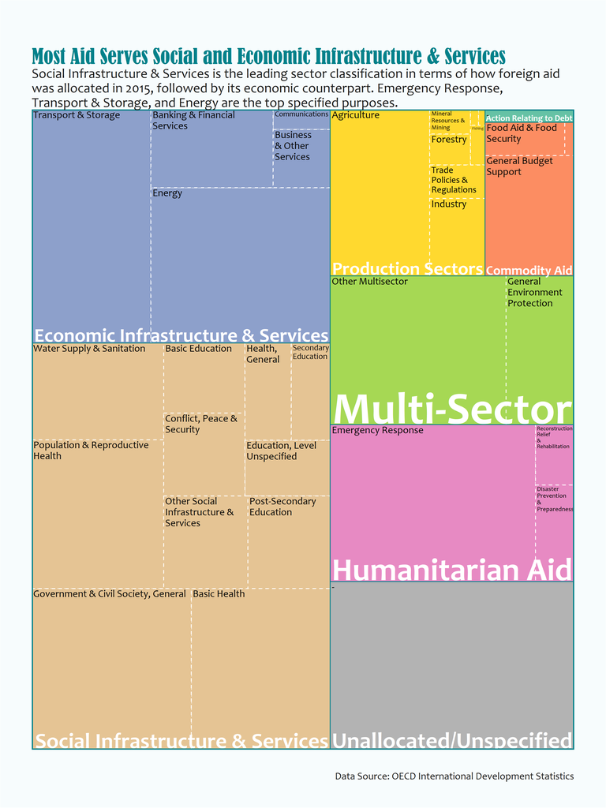

```r
sector %>%
  ggplot(aes(area=Value, subgroup=`Level 1`, fill=`Level 1`, label =`Level 2`))+
  geom_treemap(color="white", size=2, linetype = "dashed")+
  geom_treemap_subgroup_border(color="#02818a", size=2) +
  geom_treemap_subgroup_text(place="bottomright", family="Candara", grow = T, color = "White", fontface="bold", alpha=1) +
  geom_treemap_text(color = "black", place = "topleft", family="Candara", reflow = T, grow= F)+
  scale_fill_manual(values = brewer.pal(8, qualitative)) +
  scale_x_continuous(expand = c(0, 0)) +
  scale_y_continuous(expand = c(0, 0)) +
    labs(title="Most Aid Serves Social and Economic Infrastructure & Services",
       subtitle="Social Infrastructure & Services is the leading sector classification in terms of how foreign aid\nwas allocated in 2015, followed by its economic counterpart. Emergency Response,\nTransport & Storage, and Energy are the top specified purposes.",
       caption = "Data Source: OECD International Development Statistics") +
  my_theme+
  theme(legend.position = "none",
        panel.border = element_rect(color="#02818a", size=2, fill=NA),
        plot.title=element_text(vjust=0),
        plot.subtitle=element_text(vjust=0),
        plot.margin = margin(3, 2, 3, 2, "cm"))
```

> Social Infrastructure & Services is the leading sector classification in terms of how foreign aid was allocated in 2015, followed by its economic counterpart. Emergency Response, Transport & Storage, and Energy are the top specified purposes. Debt relief only accounts for a tiny portion of ODA.

## Graph 7

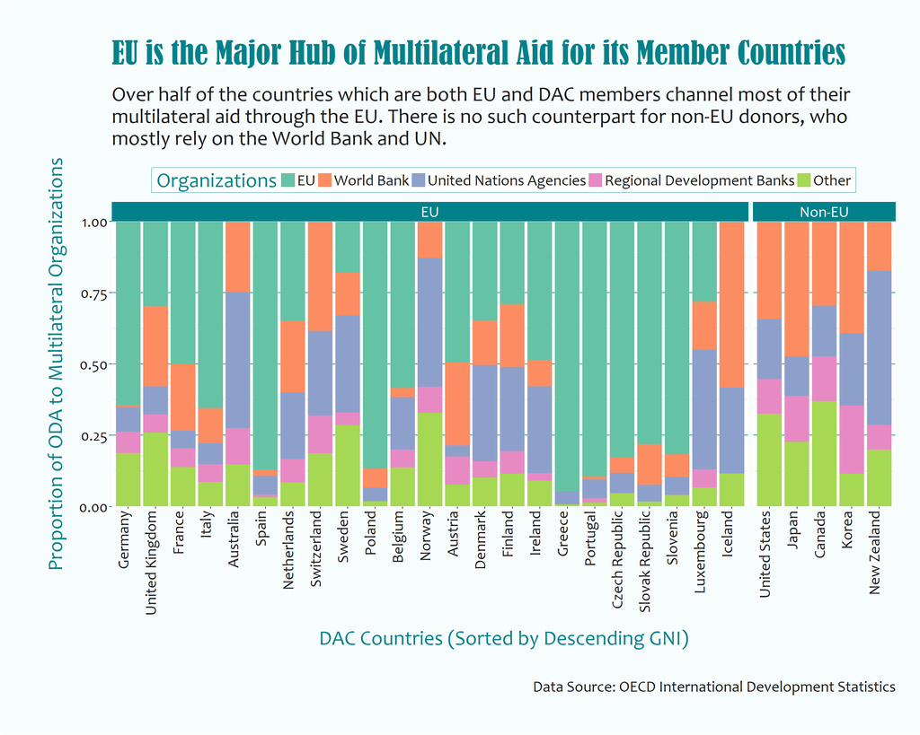

```r
multi %>%
  ggplot() +
  geom_bar(aes(x=reorder(Country, -GNI), y=Amount, fill=Organization), stat="identity", position="fill")+
  scale_y_continuous(expand = c(0, 0))+
  scale_fill_manual(values = brewer.pal(5, qualitative))+
  facet_grid(.~Region, scales="free_x", space="free_x")+
  theme(axis.text.x=element_text(angle = 90, hjust=1, vjust = 0),
        legend.position = "top")+
  labs(title="EU is the Major Hub of Multilateral Aid for its Member Countries",
       subtitle="Over half of the countries which are both EU and DAC members channel most of their\nmultilateral aid through the EU. There is no such counterpart for non-EU donors, who\nmostly rely on the World Bank and UN.",
       x="DAC Countries (Sorted by Descending GNI)",
       y="Proportion of ODA to Multilateral Organizations",
       fill="Organizations",
       caption = "Data Source: OECD International Development Statistics")+
  my_theme
```

> Over half of the countries which are both EU and DAC members channel most of their multilateral aid through the EU. There is no such counterpart for non-EU donors, who mostly rely on the World Bank and UN. There is no obvious correlation between GNI and the allocation of multilateral aid.